# NLP Seminar

Forrest Paton, McMaster University

2018-03-27

# Intro

- We’re going to explore how to setup and tune a simple classifier using Natural Language processing
- Slides (and code) available here: https://github.com/fpaton
- packages used:

```r
pacman::p_load(twitteR, dplyr, wordcloud, tm, stringr, lubridate,
               quanteda, prettydoc, knitr, ggplot2, caret, pROC,
               RColorBrewer, MASS, rBayesianOptimization, xgboost)
```

- suggested readings: [Guassian Processes in Machine Learning](https://mitpress.mit.edu/books/gaussian-processes-machine-learning), [NLP in Python](http://www.nltk.org/book/)

[figure not shown]

[figure not shown]

# Start with example… Twitter data:

Here I’ll scrape some tweets from POTUS:

```r
trump_tweets <- userTimeline("realDonaldTrump", n = 200, includeRts =F) %>%
                twListToDF()

obama_tweets <- userTimeline("BarackObama", n = 200, includeRts =F) %>%
                twListToDF()
```

Couple of rows from data we just scraped

| TRUMP | Obama |
| --- | --- |
| So much Fake News. Never been more voluminous or more inaccurate. But through it all, our country is doing great! | Michelle and I are so inspired by all the young people who made today’s marches happen. Keep at it. You’re leading… https://t.co/d0DTg594Cs |
| The economy is looking really good. It has been many years that we have seen these kind of numbers. The underlying… https://t.co/8sWXaR8gR8 | Our most important task as a nation is to make sure all our young people can achieve their dreams. We’ve started th… https://t.co/gNw9ks6pMY |

## Basic Pre processing

We’ll do some basic pre processing here and remove all the url links:

```r
trump_tweets$text <- str_replace_all(trump_tweets$text, "https.*", "")

obama_tweets$text <- str_replace_all(obama_tweets$text, "https.*", "")
```

| TRUMP | Obama |
| --- | --- |
| So much Fake News. Never been more voluminous or more inaccurate. But through it all, our country is doing great! | Michelle and I are so inspired by all the young people who made today’s marches happen. Keep at it. You’re leading… |
| The economy is looking really good. It has been many years that we have seen these kind of numbers. The underlying… | Our most important task as a nation is to make sure all our young people can achieve their dreams. We’ve started th… |

Looks better, but probably good idea to remove special symbols.. etc

```r
tweets_tokens <- tokens(c(obama_tweets$text, trump_tweets$text),
                       what = "word",
                       remove_numbers = TRUE,
                       remove_punct   = TRUE,
                       remove_symbols = TRUE,
                       remove_hyphens = TRUE) %>% tokens_tolower()
```

### StopWords and Stemming

```r
head(stopwords(), n=10)
```

```
##  [1] "i"         "me"        "my"        "myself"    "we"
##  [6] "our"       "ours"      "ourselves" "you"       "your"
```

Next are stopwords, think about if it makes sense to remove these in your model.

```r
# remove stopwords
tweets_tokens <- tokens_select(tweets_tokens, stopwords(), selection="remove")
head(tweets_tokens)[1]
```

```
## tokens from 1 document.
## text1 :
##  [1] "incredible"      "chicago"         "team"
##  [4] "final"           "four"            "take"
##  [7] "intact"          "bracket"         "day"
## [10] "congratulations"
```

Next we’ll stem the words, definition from Wikipedia:

> In linguistic morphology and information retrieval, stemming is the process of reducing inflected (or sometimes derived) words to their word stem, base or root form—generally a written word form

```r
# stem words
tweets_tokens <- tokens_wordstem(tweets_tokens, language = "english")
tweets_tokens[1]
```

```
## tokens from 1 document.
## text1 :
##  [1] "incred"    "chicago"   "team"      "final"     "four"
##  [6] "take"      "intact"    "bracket"   "day"       "congratul"
```

# Some Exploratory Analysis

Here are each president’s top words tweeted (can you guess who’s who?)

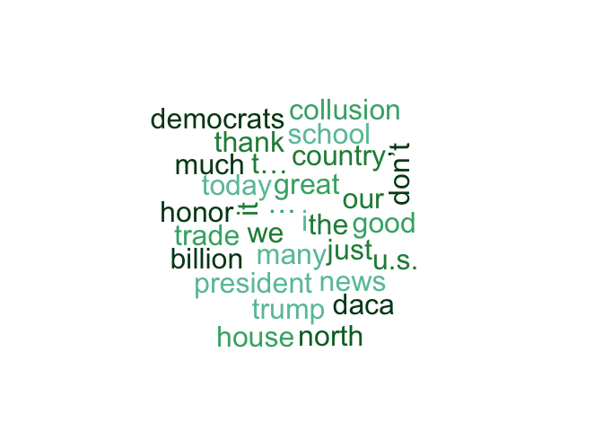

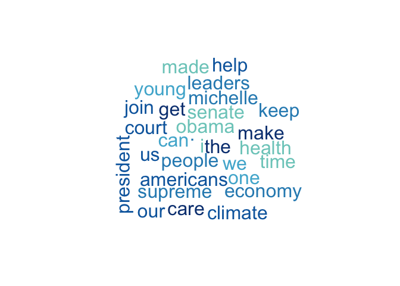

## What time of day are they tweeting at

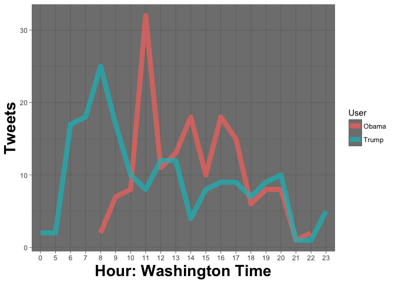

# Modelling a classifier

We’re going to build a model that, given a tweet, will predict whether it came from President Trump or President Obama.

That is we want a model in some general form:

$$P(\text{Tweet = Trump}) = f(\bf{X}) + \epsilon$$
Challenges:

- Need feature matrix
- How to model $f()$
- Compute time

## Create a feature matrix

Key Ideas:

- Represent Each Word in a matrix…
  - cell(i, j) = # of times word appears
  - all words are equally important
- Represent Each Word as a column in a matrix…
  - cell(i, j) = inverse document frequency (${idf}_t$)

Where

$${idf}_t = \ln(\frac{N}{df_t})$$
Defining ${df}_t =$ # of tweets that contain word $t$ and $N$ as the number of tweets then

```r
model.tokens.dfm    <- dfm(tweets_tokens, tolower=FALSE)
model.tokens.matrix <- model.tokens.dfm %>% as.matrix()

model.tokens.df <- model.tokens.dfm %>% as.data.frame()

# Create labels for model
labels_pres <- c(rep("Obama", nrow(obama_tweets)),
                 rep("Trump", nrow(trump_tweets)))

data_tweets <- cbind(model.tokens.df, "Which_President" = labels_pres) %>%
                mutate(Which_President = as.factor(Which_President))
```

small subset of data frame: data_tweets

| incred | team | th | lead | parkland | need | inspir | Which_President |
| --- | --- | --- | --- | --- | --- | --- | --- |
| 1 | 1 | 0 | 0 | 0 | 0 | 0 | Obama |
| 0 | 0 | 0 | 1 | 0 | 0 | 1 | Obama |
| 0 | 0 | 1 | 0 | 0 | 0 | 0 | Obama |
| 0 | 0 | 0 | 0 | 0 | 0 | 0 | Trump |
| 0 | 0 | 0 | 0 | 0 | 0 | 0 | Trump |
| 0 | 0 | 0 | 0 | 0 | 0 | 0 | Trump |

```r
nrow(data_tweets)
```

```
## [1] 345
```

```r
ncol(data_tweets)
```

```
## [1] 1367
```

```r
nrow(filter(data_tweets, Which_President== "Trump"))
```

```
## [1] 186
```

```r
nrow(filter(data_tweets, Which_President== "Obama"))
```

```
## [1] 159
```

# Build Model with our feature matrix

```r
set.seed(123)
# create partition
inTrain <- createDataPartition(data_tweets$Which_President,
                               p = .90, list=FALSE)

# Split the data:
training <-  data_tweets %>% dplyr::slice(inTrain)
testing  <-  data_tweets %>% dplyr::slice(-inTrain)
```

```r
# train model
control <- trainControl(method = "cv", number = 5,
                        savePredictions = TRUE, classProbs = TRUE)

xgGrid <- expand.grid(
    nrounds   = c(50),
    max_depth = c(2,3,4),
    eta       = c(.1, .2, .3, .4, .5),
    gamma     = c(0.01),
    colsample_bytree = c(0.75),
    subsample = c(0.50),
    min_child_weight = c(0))

model_caret_1 <- Which_President ~ .

# Train Model

train_mod_xg <- caret::train(model_caret_1, data = training,
                             method="xgbTree", trControl=control,
                             tuneGrid = xgGrid) # our favourite, xgb

predictions_xg <- predict(train_mod_xg, testing[, -ncol(testing)], type = "prob" )

predictions_class_xg <- predict(train_mod_xg, testing[, -ncol(testing)])

table(predictions_class_xg, testing$Which_President)
roc(as.numeric(testing$Which_President), predictions_xg$Obama)
```

`system.time(train_model) = 25.8s`

## Cross validation results (and problems with naive grid search)

Imagine if we started at `shrinkage = .1` …

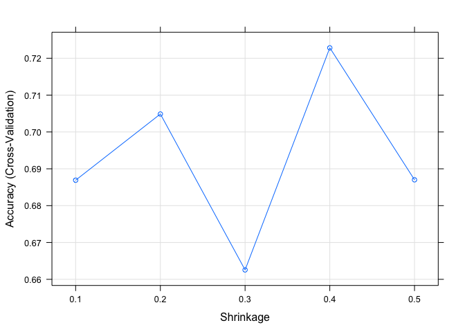

Best parameter choices for XGBoost

| nrounds | max_depth | eta | gamma | colsample_bytree | min_child_weight | subsample |
| --- | --- | --- | --- | --- | --- | --- |
| 50 | 3 | 0.4 | 0.01 | 0.75 | 0 | 0.5 |

### How many parameters to optmize?

There are seven parameters with a varying range of levels, realistically we might want to try these levels:

```r
xgGrid <- expand.grid(
    nrounds   = c(50, 150, 250, 350),
    max_depth = c(3, 6, 9, 12, 30, 40),
    eta       = c(.1, .2, .3, .4, .5),
    gamma     = c(0.01, .1, 2),
    colsample_bytree = c(0.75),
    subsample = c(0.50),
    min_child_weight = c(0))
```

That is tuning a model: $4*6*5*...$, if `proc time` > a few hours this problem blows up.

- Options to deal with compute time:
  - train on Cloud
  - find more grad students
  - … Bayesian Optimization

# Bayesian Optimization

Useful for black box optimization. Since we don’t know the objective function cannot use our regular methods (EM, NR). We’ll set a prior over what kind of function we think it might look like: smooth, high variance, etc. (the bayesian part) and we’ll optmize over where to explore next.

### Key Points:

- Have unkown objective function want to maximize/minimize (could be RMSE, accuracy)
- Set Prior distribution on this function (gaussian process)
- Explore regions with high uncertainty - exploit regions with high (predicted) objective function

## Some basics:

A Gaussian process is…

> a collection of random variables, any finite number of which have a joint Gaussian distribution (Rasmussen, 2006)

$$m(x) = E[f(x)] \\
k(x, x') = E[(f(x)-m(x))\ (f(x') - m(x'))]
\\$$

Then our GP is defined:

$$f(x) \sim GP(m(x), \ k(x, x')) \ \ \text{}$$
Where its common to let m(x) = 0. The standard covariance function k is often defined as $k(x_i, x_j) = \exp\big\{ -\frac{1}{2} (x_i - x_j)^2\big\}$ called the squared exponential and we’ll define it here as K1:

```r
K1 <- function(s,t) return(exp(-16*(s-t)^2))
```

We’ll setup our posterior predictive GP as follows: we sample our objective function $D_{1:t} = (x_{1:t}, \ y_{1:t})$ and combine it with our prior $f$ to get $P(f \ |D_{1:t})$ $\propto$ $P(D_{t:1} \ | \ f) \ P( \ f \)$

GP’s have nice properties, since they’re gaussian, if we have evaulated our function with parameter values (assume $\theta = \text{our hyperparameter} = x$) $\{x{1:t}, \ f_{1:t}\}$ then our next parameter value $x_{t+1}$ evaluated at $f_{t+1}=f(x{t+1})$ we know:

$$\textbf{K} =
\begin{bmatrix}
k(x_{1}, \ x_{1}) & ... & k(x_{1}, \ x_{t}) \\
... & ... & ...\\
k(x_{t}, \ x_{1}) & ... & k(x_{t}, \ x_{t})
\end{bmatrix}$$

Then it follows:

$$\begin{pmatrix}
\bf{f_{1:t}} \\
f_{t+1}
\end{pmatrix}
\sim
N\Big( \bf{0}, \
\begin{bmatrix}
\bf{K} & \bf{k} \\
\bf{k}^T & k(x_{t+1}, \ x_{t+1})
\end{bmatrix}$$

here $\bf{k}$ = $[k(x_{t+1}, x_1), k(x_{t+1}, x_2), ..., \ k(x_{t+1}, x_t)]$ leading to our predictive disribution:

$$P(f_{t+1} | D_{1:t}) = N(\mu_t(x_{t+1}), \ \sigma^2_t(x_{t+1}))$$

where the mean and variance can be worked out:

$$\mu_t(x_{t+1}) = \bf{k}\bf{K}^{-1}\bf{f}_{1:t} \\
\sigma^2_t(x_{t+1}) = k(x_{t+1}, x_{t+1}) - k_{t+1}(K^{-1})k_{t+1}$$

> See chapter 2 Rasmussen for full details

## Quick example

```r
t <- seq(from = 0, to = 1, length.out = 1000) # x to sample from
#compute covariance matrix
Sigma <- sapply(t, function(s1) {
    sapply(t, function(s2) {
      K1(s1, s2)
    })
  })

path <- mvrnorm(mu = rep(0, times = 1000), Sigma = Sigma)
x   <- data.frame("t" = t, "xt" = path, "label"= rep("x", 1000))
```

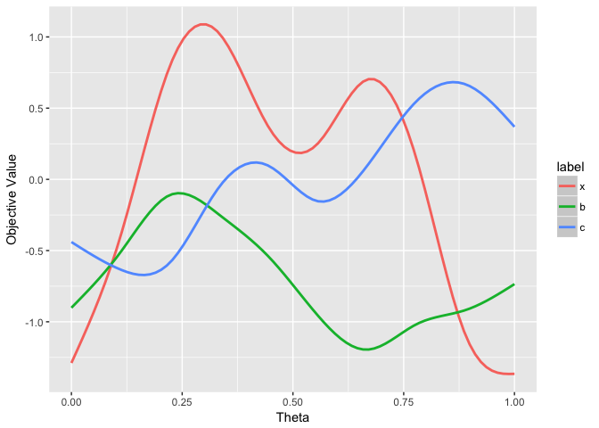

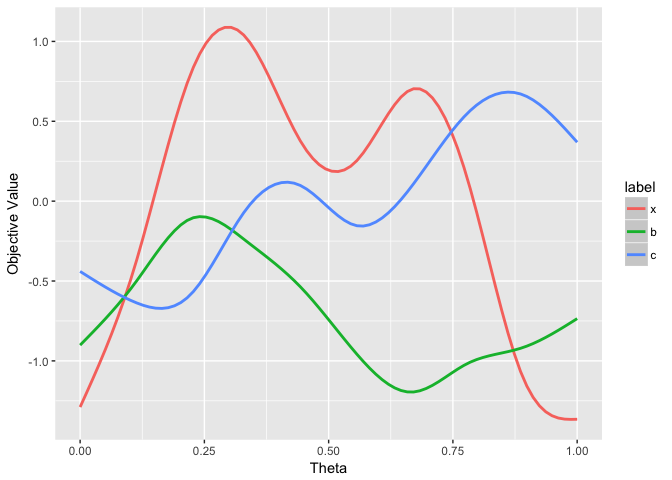

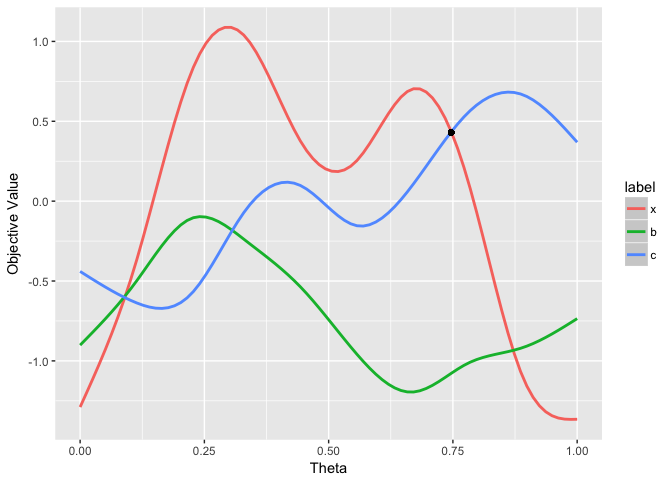

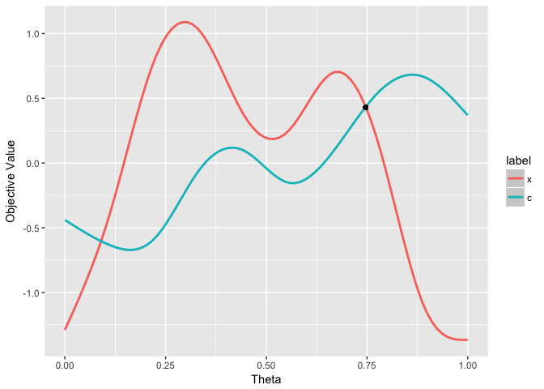

## Implementing Bayesian Optimization

```r
training_xg <- training %>% dplyr::select(-Which_President)
dtrain <- xgb.DMatrix(as.matrix(training_xg), label = as.matrix(as.numeric(training$Which_President) -1) )

cv_folds <- KFold(training$Which_President, nfolds = 5,
                  stratified = TRUE, seed = 0)

xgb_cv_bayes <- function(max.depth, eta) {

  cv   <- xgb.cv(params = list(booster = "gbtree", eta = eta,
                             max_depth = max.depth,
                             min_child_weight = 0,
                             subsample = .5, colsample_bytree = 0.3,
                             lambda = 1, alpha = 0,
                             objective = "binary:logistic",
                             eval_metric = "auc"),
               data = dtrain, nround = 50,
               folds = cv_folds, prediction = TRUE, showsd = TRUE,
               early_stopping_rounds = 5, maximize = TRUE, verbose = 0)

  list(Score = cv$evaluation_log[, max(test_auc_mean)], Pred = cv$pred)
}

OPT_Res <- BayesianOptimization(xgb_cv_bayes,
                                bounds = list(max.depth = c(3L, 5L),
                                              eta = c(0.1, 0.5)),
                                init_grid_dt = NULL, init_points = 10, n_iter = 20,
                                acq = "ucb", kappa = 2.576, eps = 0.0,
                                verbose = TRUE)
```

## Results from bayesopt

Best Parameters Found: max.depth = 4.0000 eta = 0.3325 Value = 0.8003

```r
control <- trainControl(method = "cv", number = 5,
                        savePredictions = TRUE, classProbs = TRUE)

xgGrid_bayes <- expand.grid(
    nrounds   = c(50),
    max_depth = 4,
    eta       = c(.3325),
    gamma     = c(0.01),
    colsample_bytree = c(0.75),
    subsample = c(0.50),
    min_child_weight = c(0))

model_caret_1 <- Which_President ~ .

# Train Model
train_mod_bayes <- caret::train(model_caret_1, data = training,
                             method="xgbTree", trControl=control,
                             tuneGrid = xgGrid_bayes) # same but now with optimized

predictions_xgb_bayes <- predict(train_mod_bayes, testing[, -ncol(testing)], type = "prob" )

predictions_class_xbg_bayes <- predict(train_mod_bayes, testing[, -ncol(testing)])
```

```r
# bayesian optimization

table(predictions_class_xbg_bayes, testing$Which_President)
```

```
##
## predictions_class_xbg_bayes Obama Trump
##                       Obama    11     1
##                       Trump     4    17
```

```r
roc(as.numeric(testing$Which_President), predictions_xgb_bayes$Obama)$auc
```

```
## Area under the curve: 0.9037
```

```r
table(predictions_class_xg, testing$Which_President)
```

```
##
## predictions_class_xg Obama Trump
##                Obama    11     2
##                Trump     4    16
```

```r
roc(as.numeric(testing$Which_President), predictions_xg$Obama)$auc
```

```
## Area under the curve: 0.8593
```